# Qual o jogo mais popular da plataforma Twitch?

Trabalho de Conclusão do curso ‘R para Ciência de Dados 1’. Autoria: Victor Alves Dogo Martins

# Introdução

Jogos de videogame tomaram o mundo como uma avalanche. É difícil encontrar alguém que não tenha ouvido falar deles e, entre essas pessoas, praticamente impossível encontrar alguém sem opinião formada, seja a favor ou contra.

Mais recentemente, surgiu um fenômeno curioso nessa comunidade: pessoas que transmitem ao vivo suas jogatinas para milhares de espectadores e fazem disso seu ganha pão. Carinhosamente apelidades de *streamers*, são parte vital da comunidade e possuem atenção das empresas. Afinal, constituem uma espécie de marketing.

Entre as plataformas de streaming, a mais conhecida é a Twitch.tv. Nela, as transmissões são separadas por categorias relativas aos jogos que são jogados. Para a sorte de nós, estatísticos e cientistas de dados, a avalanche de informações resultante de todo esse processo é disponibilizada para estudos dos mais diversos tipos.

A finalidade deste trabalho, portanto, é identificar **qual dos jogos transmitidos é o mais popular.** Para isso, primeiro é interessante entendermos como é nosso banco de dados.

# O Banco de Dados

O banco de dados utilizados é o [Top Games on Twitch 2016 - 2021](https://www.kaggle.com/rankirsh/evolution-of-top-games-on-twitch), e conta com diversas observações relativas às transmissões dos jogos na plataforma.

As variáveis disponíveis são as seguintes:

Tabela 1: Descrição do banco de dados

| Variável | Descrição |
| --- | --- |
| Rank | Rank Mensal (1-200) |
| Jogo | Nome do jogo ou categoria |
| Mês | Mês em questão |
| Ano | Ano em questão |
| Horas Assistidas | Horas totais assistidas na Twitch |
| Horas Transmitidas | Horas totais transmitidas na Twitch |
| Pico de Espectadores | Maior número de espectadores do jogo no mesmo instante |
| Pico de Canais | Maior número atingido de canais transmitindo o jogo no mesmo instante |
| Streamers | Número de streamers que transmitiram o jogo |
| Média de Espectadores | Número médio de espectadores por transmissão |
| Média de Canais | Número médio de canais transmitindo o jogo |
| Razão Média de Espectadores | Razão Média de espectadores por canal transmitindo o jogo |

Perfeito: com as variáveis apropriadamente descritas, podemos partir para a apresentação propriamente dita de nosso banco de dados. Convém mostrarmos um trecho dele para entendermos como ele é constituído. Isso é facilmente obtível através da função *head()* no R.

Tabela 2: Trecho do dataset

| rank | jogo | mes | ano | horas_assistidas | horas_transmitidas | pico_espectadores | pico_canais | streamers | media_espectadores | media_canais | razao_media_espectadores |
| --- | --- | --- | --- | --- | --- | --- | --- | --- | --- | --- | --- |
| 1 | League of Legends | 01 | 2016 | 94377226 | 1362044 | 530270 | 2903 | 129172 | 127021 | 1833 | 69.29 |
| 2 | Counter-Strike: Global Offensive | 01 | 2016 | 47832863 | 830105 | 372654 | 2197 | 120849 | 64378 | 1117 | 57.62 |
| 3 | Dota 2 | 01 | 2016 | 45185893 | 433397 | 315083 | 1100 | 44074 | 60815 | 583 | 104.26 |
| 4 | Hearthstone | 01 | 2016 | 39936159 | 235903 | 131357 | 517 | 36170 | 53749 | 317 | 169.29 |
| 5 | Call of Duty: Black Ops III | 01 | 2016 | 16153057 | 1151578 | 71639 | 3620 | 214054 | 21740 | 1549 | 14.03 |
| 6 | Minecraft | 01 | 2016 | 10231056 | 490002 | 64432 | 1538 | 88820 | 13769 | 659 | 20.88 |

# O que é ser o jogo mais popular da plataforma?

As variáveis apresentadas no banco de dados são muitas. Fica difícil batermos o martelo e dizermos que *essa* ou *aquela* variável é decisiva para descobrirmos quais dos jogos acima apresentados é, de fato, o mais popular da plataforma Twitch.

Podemos raciocinar, passo a passo, na busca de quais variáveis levarmos em consideração:

1. O Rank Mensal é um bom indicador de como determinado jogo é visto ao longo do tempo (isto considerando que os critérios para este rank sejam adequados!), podendo servir para escolhermos nossos candidatos;
2. As horas assistidas e transmitidas, por outro lado, constituem parte importante do ecossistema da plataforma, indicando o quão popular determinado jogo é no geral;
3. O pico de canais e espectadores de cada jogo é um bom indicativo quão popular determinado jogo é/já foi;
4. A razão média mensal de espectadores por canal, por fim, pode nos mostrar o quão fiel/assíduo o público de determinado jogo é.

Outras variáveis acabam por mostrar insights muito parecidos e, por conta disso, não serão levadas em consideração para evitarmos que a análise seja muito redundante.

Perfeio, temos um breve delineamento de onde devemos nos focar. O objetivo deste trabalho, portanto, é **determinar o jogo mais popular da Twitch levando em conta os quatro pontos mencionados acima.**

> OBS: Para alguns gráficos que serão apresentados à seguir, alguns nomes foram abreviados de acordo com seu uso mais recorrente dentro da comunidade. Isso ajudou a deixá-los mais sucintos mas, caso tenha dificuldade, segue um pequeno resumo de suas abreviações:

Tabela 3: Dicionário de Abreviações

| Era | Virou |
| --- | --- |
| League of Legends | LoL |
| Grand Theft Auto V | GTA V |
| Call of Duty: Warzone | CoD: Warzone |
| Counter Strike: Global Offensive | CS:GO |
| World of Warcraft | WoW |

# Vamos para as Análises!

## Rank Mensal

### Escolha dos jogos de acordo com rank médio

O rank médio em questão leva em conta **toda a extensão do banco de dados**, ou seja, não é calculado para cada ano/mês e sim para todo o tempo compreendido em nosso dataset. A intenção é limitarmos nossa análise aos 10 jogos que possuam maior rank médio mensal calculado no período de 2016 a 2021.

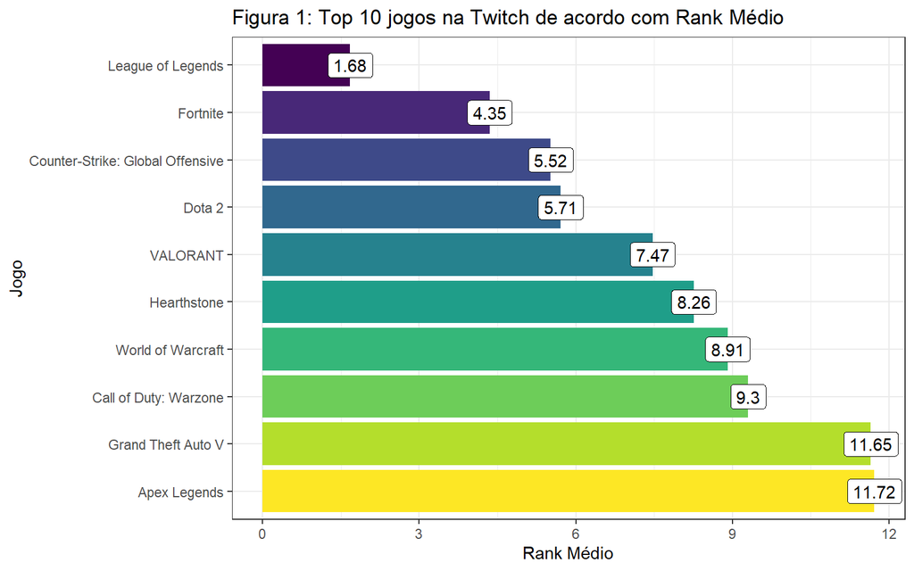

Fãs de jogos MOBA ou estão muito tristes ou muito felizes: LoL encontra-se à frente no ranking, quase isolado, superando por 4.03 pontos seu rival, Dota 2. É seguido por Fortnite, CS:GO, Valorant, Hearthstone, WoW, CoD: Warzone, GTA V e Apex Legends. Na esmagadora maioria, os membros deste Top 10 são velhos conhecidos da comunidade de jogos competitivos, possuindo campeonatos nacionais e internacionais patrocinados inclusive pelas suas respectivas empresas desenvolvedoras.

### Rank Médio com o passar dos anos

Além do rank médio mensal total, podemos avaliar como os jogos acima encontrados se comportam no período de 2016 à 2021:

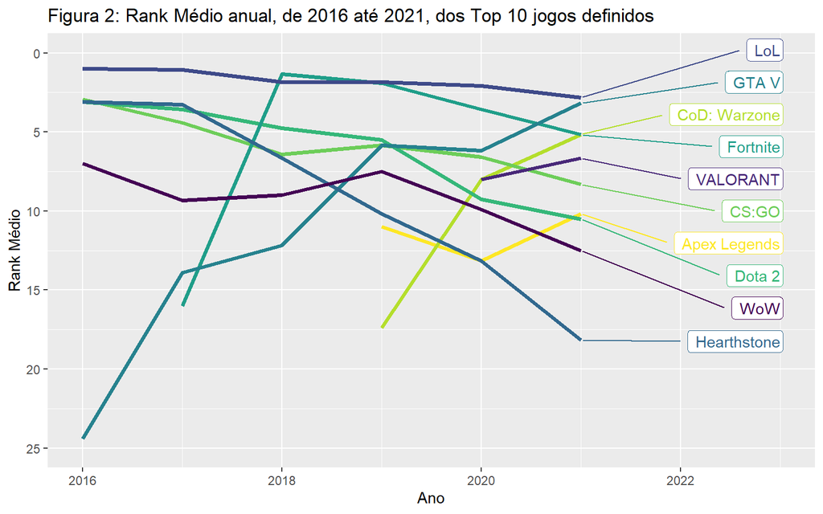

Dos jogos apresentados acima, o com o melhor desempenho à longo prazo certamente é o LoL: veterano da plataforma, é o único que não perdeu sua colocação para jogos mais recentes, mantendo-se em primeiro lugar e estável por grande parte do tempo, chegando a perder por pouco para Fortnite em 2018.

Outro destaque vai para VALORANT que, em um ano de existência, já figura entre os 5 mais populares segundo o quesito apresentado em nosso estudo. Hearthstone, coitado, figurando como terceiro mais popular em 2016 caiu para o décimo lugar, perdendo espaço para seus competidores mais joviais.

Da figura acima, temos que LoL é um forte candidato a jogo mais popular da plataforma dado sua posição em 2021 e sua estabilidade com o passar do tempo. Logo depois dele, temos CoD: Warzone, GTA V e Fornite com comportamentos menos homogêneos mas com boas colocações ao longo do tempo.

## Horas Assistidas e Transmitidas

Além do rank, métrica fornecida pela plataforma para nós, convém analisarmos as horas assistidas e transmitidas.

Tabela 4: Top 10 jogos definidos ordenados por horas totais assistidas

| Jogo | Horas Totais Assistidas |
| --- | --- |
| League of Legends | 6.664.611.934 |
| Fortnite | 4.143.704.994 |
| Counter-Strike: Global Offensive | 2.921.523.211 |
| Grand Theft Auto V | 2.767.974.487 |
| Dota 2 | 2.698.350.543 |
| Hearthstone | 1.934.218.330 |
| World of Warcraft | 1.644.337.720 |
| Call of Duty: Warzone | 1.419.531.059 |
| VALORANT | 1.293.368.923 |
| Apex Legends | 983.964.976 |

Tabela 5: Top 10 jogos definidos ordenados por horas totais transmitidas

| Jogo | Horas Totais Transmitidas |
| --- | --- |
| Fortnite | 275.193.901 |
| League of Legends | 132.479.023 |
| Call of Duty: Warzone | 79.663.641 |
| Apex Legends | 68.962.599 |
| Counter-Strike: Global Offensive | 59.889.156 |
| World of Warcraft | 55.315.190 |
| Grand Theft Auto V | 50.044.009 |
| VALORANT | 47.666.265 |
| Dota 2 | 29.501.709 |
| Hearthstone | 11.948.505 |

Podemos ver que há certa diferença entre a popularidade dos jogos no que diz respeito à seus *espectadores* e *transmissores*. LoL, por exemplo, possui o maior número de horas totais assistidas, mas fica atrás de Fornite quando o quesito é horas totais transmitidas; Hearthstone, da mesma forma, fica na sexta colocação quando o assunto são seus espectadores, mas cai para a lanterna (coitado!) em horas transmitidas.

A princípio, Fornite e LoL se destacam; tomando a dianteira segundo as variáveis em questão, deixam CoD: Warzone e GTA V comendo poeira, diferente do que foi observado na **Figura 2**.

No entanto, convém visualizarmos melhor a relação entre horas assistidas e transmitidas com a razão média de espectadores. Por sorte, como pudemos ver no início deste relatório, ela já nos é dada.

## Razão Média de Espectadores

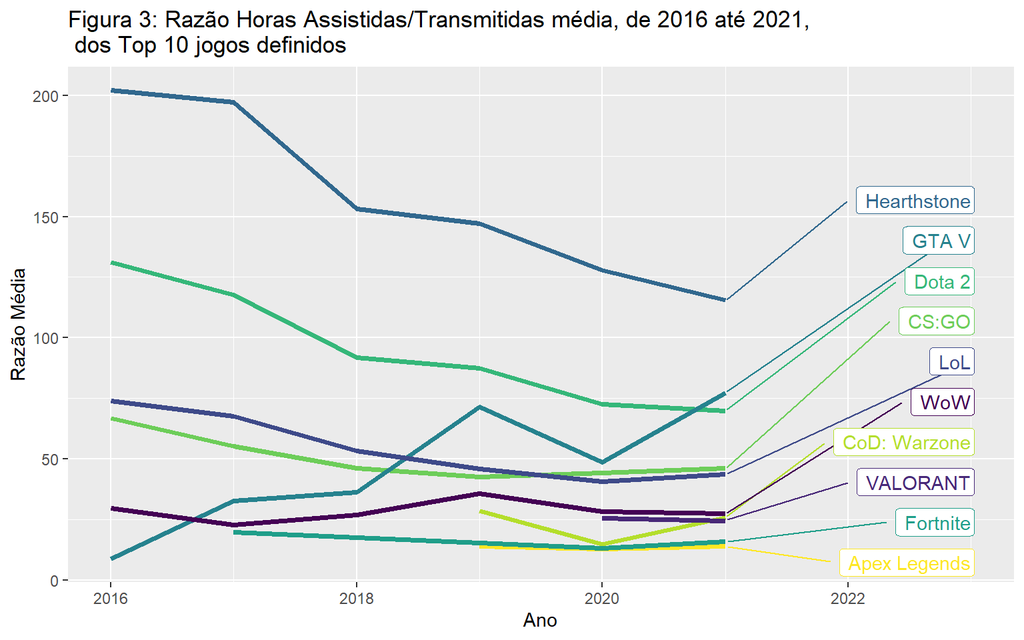

Temos um resultado surpreendente: ao invés de presenciarmos LoL ou Fornite mais bem colocados, Hearthstone toma a dianteira isolada quando analisamos a razão horas assistidas/transmitidas. Apesar da variável não poder atestar que ele seja possivelmente o jogo mais popular, não restam dúvidas de que é o jogo que possui o público mais assíduo (dado o número de horas assistidas para cada hora transmitida).

## Pico de Canais e Espectadores

Em último lugar, mas não menos importante, temos que o pico de canais e espectadores de um jogo é um indicativo do quão popular determinado jogo é (ou já chegou a ser).

Tabela 6: Top 10 jogos definidos ordenados por maior pico de espectadores

| Jogo | Maior Pico de Espectadores |
| --- | --- |
| Fortnite | 2.331.987 |
| League of Legends | 2.020.835 |
| VALORANT | 1.728.977 |
| Call of Duty: Warzone | 1.629.284 |
| Counter-Strike: Global Offensive | 1.298.358 |
| Grand Theft Auto V | 1.140.656 |
| World of Warcraft | 1.103.295 |
| Dota 2 | 1.045.985 |
| Apex Legends | 666.868 |
| Hearthstone | 331.248 |

Tabela 7: Top 10 jogos definidos ordenados por maior pico de canais

| Jogo | Maior Pico de Canais |
| --- | --- |
| Fortnite | 129.860 |
| Call of Duty: Warzone | 31.506 |
| World of Warcraft | 25.791 |
| Apex Legends | 18.932 |
| VALORANT | 16.287 |
| League of Legends | 11.606 |
| Grand Theft Auto V | 7.043 |
| Counter-Strike: Global Offensive | 5.542 |
| Hearthstone | 2.277 |
| Dota 2 | 1.810 |

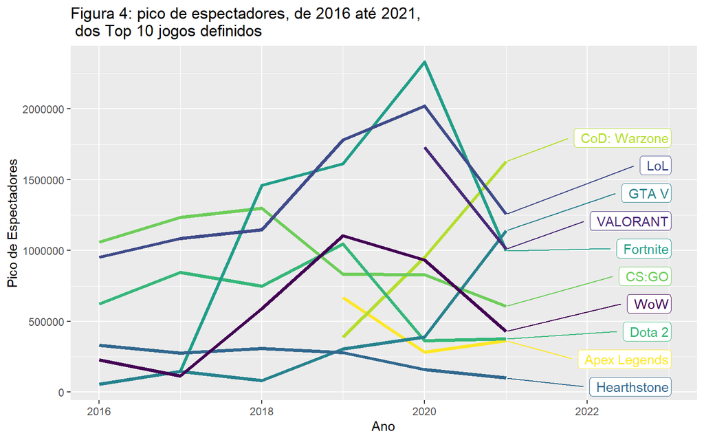

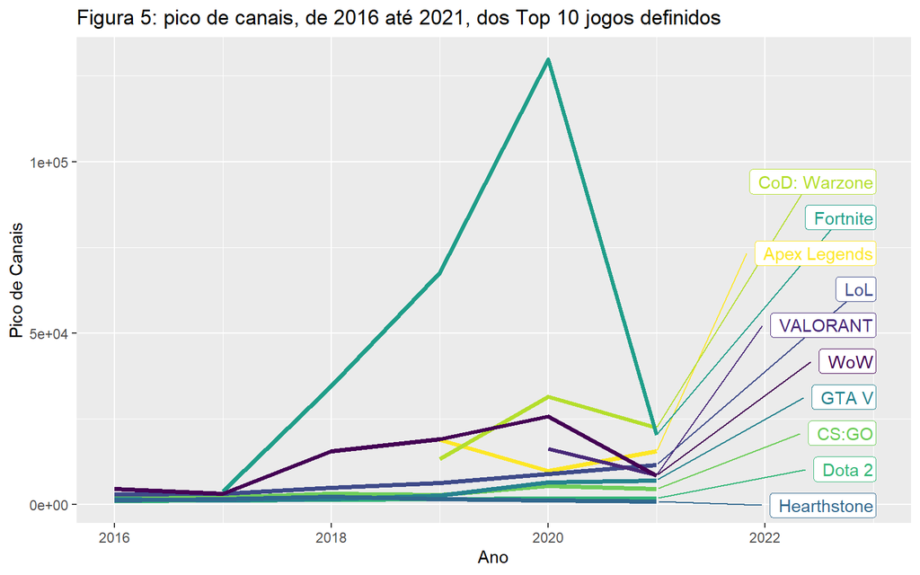

Na Figura 4, temos que Fornite e LoL manteram-se bastante fortes ao longo dos anos, com destaque para o LoL que manteve-se mais estável e nunca deixou o Top 3 jogos no que diz respeito ao pico de espectadores.

Na Figura 5, um comportamento muito curioso salta aos nossos olhos: Fortnite deixou seus outros adversários comendo poeira, atingindo sua melhor marca de canais trasmitindo-o simultaneamente no ano de 2020. Será que a pandemia influenciou mais pessoas a transmitirem suas jogatinas na Twitch, beneficiando o jogo Fortnite?

# Breve resumo e Conclusão

Tivemos que, no que diz respeito ao Rank Mensal, em média, o jogo League of Legends se destacou, seguido por Fortnite no caso geral e outros. Analisando o rank médio anual para périodo entre 2016 e 2021, essa conclusão manteve-se, mas com o destaque para GTA V e CoD: Warzone que subiram de colocação. Possivelmente, com o término do ano de 2021 e o começo de 2022, esse cenário irá se alterar.

No que diz respeito às horas assistidas e transmitidas dos 10 jogos com maior rank médio mensal, League of Legends e Fornite competiram acirradamente, praticamente equilibrados, enquanto outros jogos permaneciam em colocações piores.

Por fim, na análise do pico de espectadores, Fortnite esteve à frente de League of Legends, mas caiu para quarto lugar em 2021 ao analisarmos os anos isolados. Na análise do pico de canais, no entanto, foi campeão indiscutível com uma marca impressionante atingida em 2020, passando de longe outros jogos.

Logo, em resumo, temos:

1. League of Legends, na análise do rank mensal, foi o jogo em destaque;
2. Nas horas assistidas/transmitidas, League of Legends e Fortnite manteram-se equilibrados;
3. Na razão média de espectadores, Hearthstone foi o improvável destaque, com League of Legends atingindo um modesto quinto lugar em 2021;
4. No pico de espectadores, no caso geral, Fortnite triunfou, mas teve uma queda brusca de 2020 para 2021, enquanto que League of Legends manteve-se em segundo lugar neste ano;
5. No pico de canais, Fortnite foi indiscutivelmente o jogo que mais se destacou.

Portanto, concluimos que:

Tabela 8: Resultados

| Jogo | Prêmio |
| --- | --- |
| Fortnite | Prêmio ‘Jogo mais popular da Twitch (até agora)’ pelo destaque no pico impressionante no número de canais simultâneos em 2020 |
| League of Legends | Prêmio ‘Segundo jogo mais popular da Twitch (até agora)’ |
| Hearthstone | Menção Honrosa ‘Pelo menos seus fãs gostam MUITO de você, não é?’ |

# Referências

- [Pacote ‘rmdformats’ com diversos layouts para html no RMarkdown (este trabalho utiliza o layout ‘robobook’)](https://github.com/juba/rmdformats);
- [Banco de Dados ‘Top Games on Twitch 2016-2021’, disponível publicamente no kaggle.com](https://www.kaggle.com/rankirsh/evolution-of-top-games-on-twitch);
- Pacotes [*ggpubr*](https://rdrr.io/cran/ggpubr/) e [*ggrepel*](https://rdrr.io/cran/ggrepel/), úteis para lidar com etiquetas em gráficos do *ggplot2*;
- Pacote [*viridis*](https://rdrr.io/cran/viridis/), que disponibiliza uma paleta de cores bastante agradável;
- [Material do curso ‘R para Ciência de Dados 1’](https://curso-r.github.io/main-r4ds-1/) ;)

Obrigado!